# Prediction in Contrast and Contrast Level Affect on Mice’s Neurons

Siwon Yoo

2024-03-12

## - Abstract -

This report provides a comprehensive analysis of the experiments performed by Steinmetz et al. (2019) focused on understanding mouse responses to various contrast levels displayed on a monitor positioned to the side of the mouse. Facilitate initial data understanding through a variety of visualizations and descriptive analyses. Subsequently, using the provided data set, a custom predictive model is developed to determine the accuracy of success rate predictions in random data instances. This study not only explains experimental results but also highlights the utility of predictive modeling techniques in discerning behavioral outcomes, thereby contributing to the advancement of research methods in neuroscience and behavioral research.

## - Exploratory Data Analysis -

In the data provided by the experiment, we tested 4 mice, namely Cori, Forssmann, Hench and Lederberg. For each mouse, a total of 3, 4, 4, and 7 sessions were performed sequentially. The variables collected from each part of the experiment are: contrast_left, contrast_right, feedback_type, mouse_name, brain_area, date_exp, spks, and time. During a session, a mouse is subjected to a number of experimental trials, which are displayed by spikes and times on the screen.

| Variables | Description |
| --- | --- |
| contrast_left | the contrast level from left monitor |
| contrast_right | the contrast level from right monitor |
| feedback_type | Indication if the trial was successful |
| mouse_name | name of the mouse experimented |
| brain_area | name of the brain area where neuron is located |
| date_exp | experiment date |
| spks | number of spikes on neuron by visuals in time |
| time | time of the visulas show up |

#### Success Rate of Each Sessions

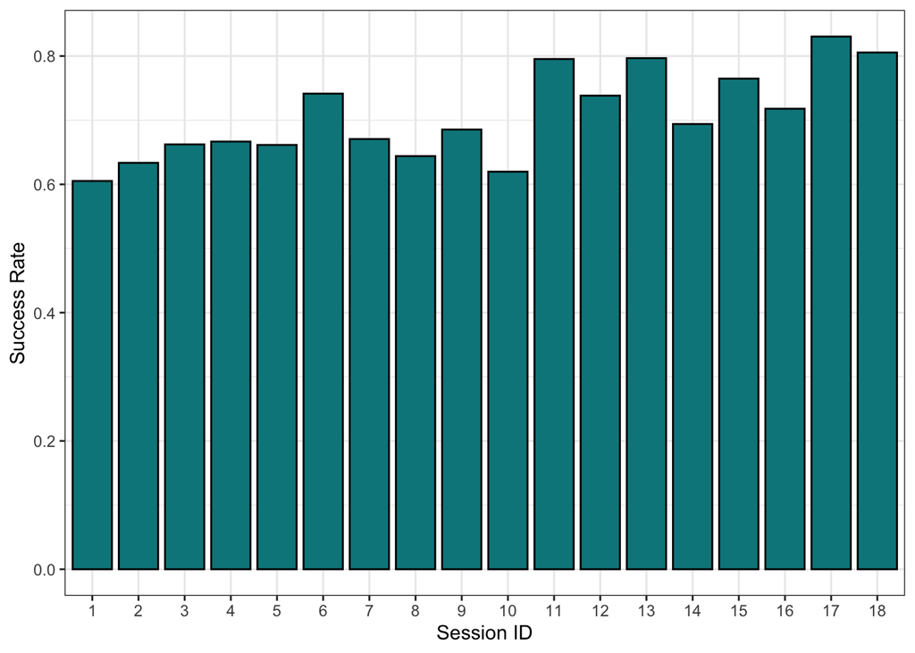

#### Success Rate Difference in Contrast Levels

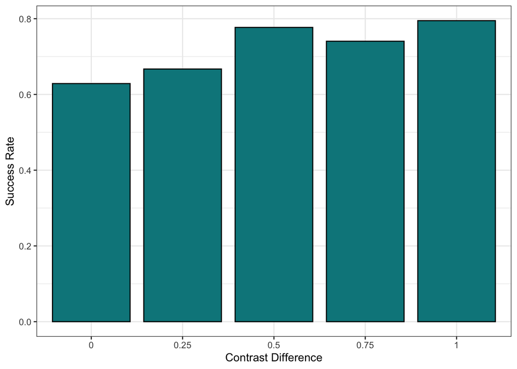

Contrast level seems to affect a lot in mice’s success rate on right move on reaction. Using the bar graph, we can see that as the contrast level increases, the mouse can easily notify the monitor and perform the correct job. It should happen because higher contrast gives more spikes on the neuron. However, contrast level 0 should be viewed differently because both monitors are turned off at this point.

#### Success Rate in Each Session with grouped trials

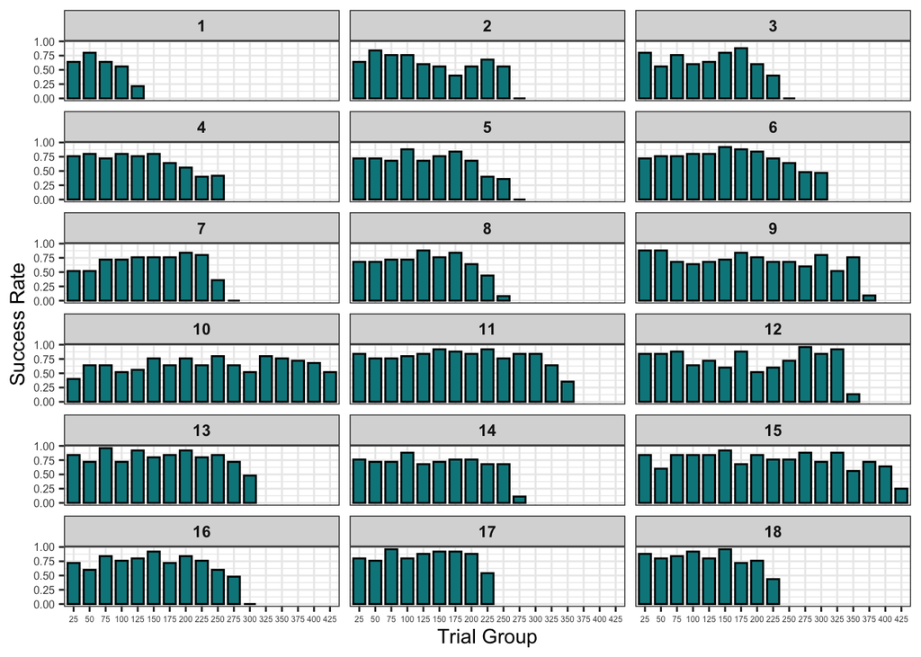

We grouped each trial in each session into 25 trials, and from the resulting graph we can see that the total number of trials varied. Also, we should not consider the last bar plot in each session plots because it mostly includes less than 25 data in each group, so the value will be a lot smaller than the others. All the data seems to have a similar success rate and there is a kind of pattern that increase in success rate at the start and later in the trial success rate decreases dramatically except few sessions.

#### Success Rate in Each Mice with grouped trials

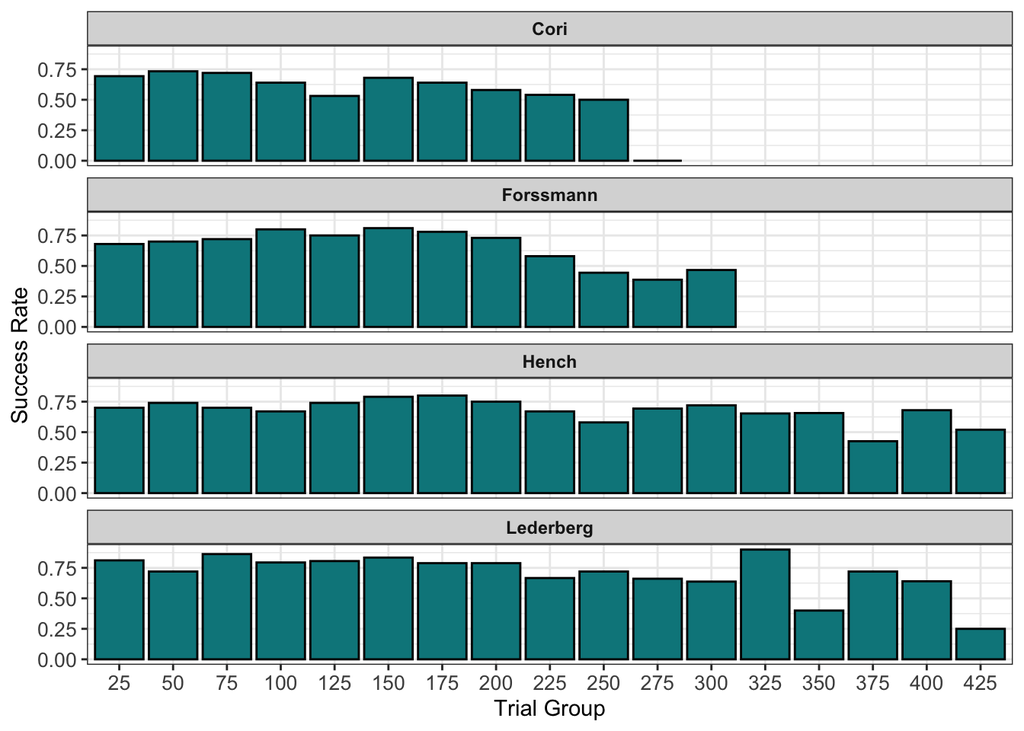

#### Mean Spike Rate for each sessions in trials

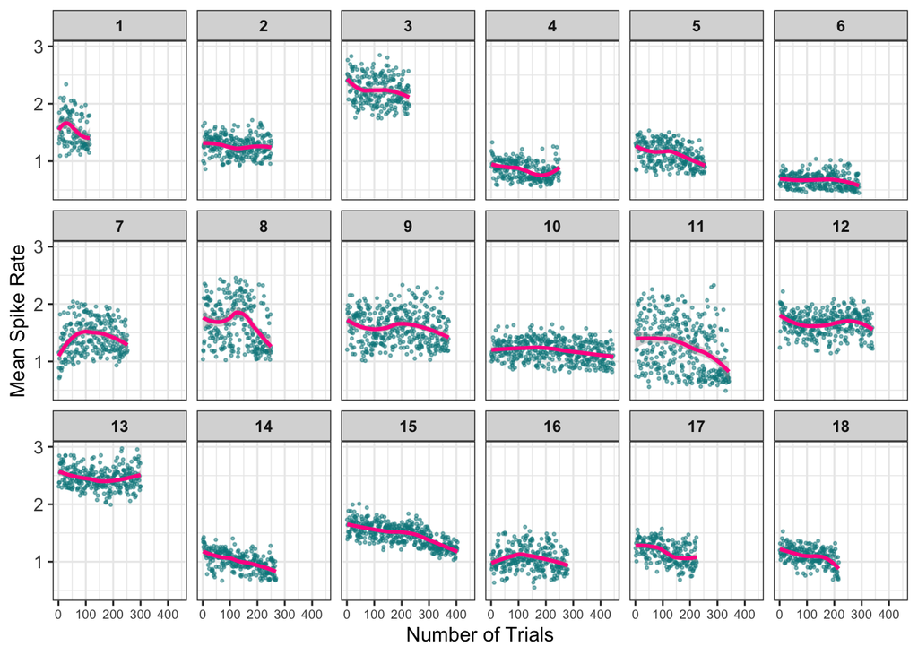

The average spike rate was considered to be all spikes produced in a single trial compared to the monitor. We don’t see any 0 average spike rates in mice, although there are some experiments that don’t compare the two.mice. Looking at the data, the range of average peak rates varies widely. However, one pattern we can see from this plot is that, except for Trial 7, the regression line ends lower than the starting point, no matter how much it rises.

#### Mean Spike Rate for Each Mice in Trials

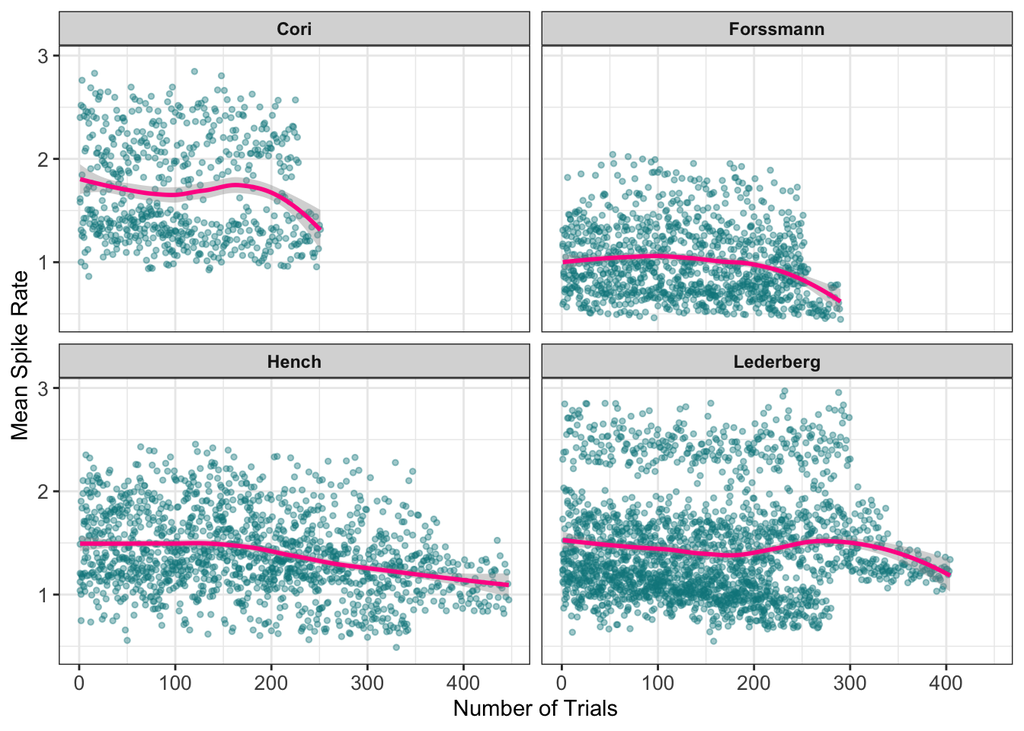

## - Data Integration -

| name | date | number_brain_area | number_neurons | number_trials | success_rate |
| --- | --- | --- | --- | --- | --- |
| Cori | 2016-12-14 | 8 | 734 | 114 | 0.61 |
| Cori | 2016-12-17 | 5 | 1070 | 251 | 0.63 |
| Cori | 2016-12-18 | 11 | 619 | 228 | 0.66 |
| Forssmann | 2017-11-01 | 11 | 1769 | 249 | 0.67 |
| Forssmann | 2017-11-02 | 10 | 1077 | 254 | 0.66 |
| Forssmann | 2017-11-04 | 5 | 1169 | 290 | 0.74 |
| Forssmann | 2017-11-05 | 8 | 584 | 252 | 0.67 |
| Hench | 2017-06-15 | 15 | 1157 | 250 | 0.64 |
| Hench | 2017-06-16 | 12 | 788 | 372 | 0.69 |
| Hench | 2017-06-17 | 13 | 1172 | 447 | 0.62 |
| Hench | 2017-06-18 | 6 | 857 | 342 | 0.80 |
| Lederberg | 2017-12-05 | 12 | 698 | 340 | 0.74 |
| Lederberg | 2017-12-06 | 15 | 983 | 300 | 0.80 |
| Lederberg | 2017-12-07 | 10 | 756 | 268 | 0.69 |
| Lederberg | 2017-12-08 | 8 | 743 | 404 | 0.76 |
| Lederberg | 2017-12-09 | 6 | 474 | 280 | 0.72 |
| Lederberg | 2017-12-10 | 6 | 565 | 224 | 0.83 |
| Lederberg | 2017-12-11 | 10 | 1090 | 216 | 0.81 |

Based on these comprehensive data, we can find that the brain areas tested are different during different training processes. The calculation of success rate is made based on the feedback_type. In the given data set, the feedback is -1 or 1, so add 1 and divide by 2 to find the total number of successes out of the total number of trials.

## - Prediction Model -

```
##
## Call:
## roc.default(response = test_label, predictor = predictions)
##
## Data: predictions in 297 controls (test_label 0) < 719 cases (test_label 1).
## Area under the curve: 0.7379
```

With the area under the curve, we can find out the accuracy of the prediction. With Receiver Operating Characteristic(ROC), we were able to find ther performance, and classifies the binary and make the roc curve to find the area under the curve.

## - Prediction performance test data -

```
##
## Call:
## roc.default(response = test_label, predictor = predictions)
##
## Data: predictions in 18 controls (test_label 0) > 22 cases (test_label 1).
## Area under the curve: 0.4747
```

## - Discussion -

From all the data, we can see that both the success rate and the average peak rate decrease over time. The area under the curve we get (i.e. under the ROC curve) helps us find the accuracy. Based on the data we have and the predictive performance test data, we can see that the numbers decrease over time, albeit with lower accuracy. Since my model performance is quite low, there should be some improvements in integrating the data and learning more about it. It would be nice to see the correlation between each brain region and find out which brain region has the highest success rate in relation to spike rate.

### Reference

Chat GPT: assisted generating the tables for the EDA, and data organization. Style of the tables. Demo and Milestone: some of the graphs and data integration, prediction model